# Study Case

Let’s use the `StormBase` package to delineate rainfall-runoff events with `test_catchment` data, which includes daily precipitation and streamflow in mm/day for a catchment in Great Britain (same and example.m in Giani et al. 2022). Following figure shows the forcing data.

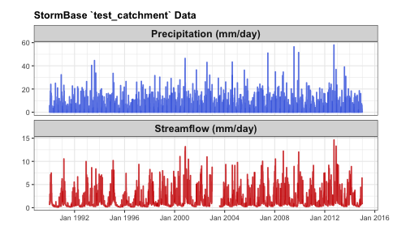

```r
test_catchment %>%
  pivot_longer(cols = c(precipitation_mmd, streamflow_mmd),
               names_to = "var", values_to = "val") %>%
  mutate(
    var = ifelse(var == "precipitation_mmd",
                 "Precipitation (mm/day)", "Streamflow (mm/day)"),
    var = ordered(var, levels = c("Precipitation (mm/day)",
                                  "Streamflow (mm/day)"))
  ) %>%
  ggplot(aes(x = Date, y = val, color = var)) +
    geom_line(linewidth = 0.6, alpha = 0.8) +
    scale_color_manual(
      values = c("royalblue", "red3"),
      guide = "none"
    ) +
    scale_x_date(
      date_breaks = "4 years",
      date_minor_breaks = "1 year",
      date_labels = "%b %Y"
    ) +
    facet_wrap(vars(var), ncol = 1, scales = "free_y") +
    labs(x = "", y = "",
         subtitle = "StormBase `test_catchment` Data") +
    theme(
      plot.subtitle = element_text(face = "bold", size = 9),
      strip.text = element_text(face = "bold", size = 9),
      plot.margin = margin(t = 10, r = 25, b = 10, l = 10)
    )
```

Now we can identify the rainfall-runoff events by assuming the precipitation is in the form of liquid water input or pure rainfall. We need to set only two parameters as following:

1. $R_{min}$: A minimum significant water input (rainfall) intensity to terminate events.
2. $L_{max}$: Maximum window length used for the detrended moving-average cross-correlation analysis (DMCA) when searching for the optimal window size, defined as $2T_r+1$. Here, $T_r$ represents the characteristic catchment response time, expressed in the same units as the forcing data (daily in this case).

In this document, we used a default value of 0.02 mm/hr (corresponding to about 0.5 mm/day) for $R_{min}$ and 100 time steps (days) for $L_{max}$.

```r
events_df <- event_identifier(
  datetime = test_catchment$Date,
  water_input = test_catchment$precipitation_mmd,
  flow = test_catchment$streamflow_mmd,
  # Bellow are default values (more details are in ?event_identifier)
  is_daily = TRUE, # running with daily data
  Rmin = 0.02,
  Lmax = 100,
  baseflow_flag = TRUE, # provided flow is the total streamflow, so it asks to
  # calculate and subtract baseflow values for runoff volume and runoff ratio
  # calculations
  exclude_na = TRUE # it removes events with missed streamflow values since
  # those values are treated as 0 for volume calculations (na.rm = TRUE).
)
```

```r
summary(events_df)
```

```
#>  waterInput_start     waterInput_end       waterInput_duration waterInput_volume stormflow_start
#>  Min.   :1990-01-05   Min.   :1990-03-04   Min.   :  1.00      Min.   :  0.591   Min.   :1990-01-06
#>  1st Qu.:1996-02-24   1st Qu.:1996-02-28   1st Qu.:  4.00      1st Qu.:  9.921   1st Qu.:1996-02-24
#>  Median :2001-10-25   Median :2001-11-04   Median :  7.00      Median : 23.942   Median :2001-10-26
#>  Mean   :2002-03-10   Mean   :2002-03-20   Mean   : 10.99      Mean   : 42.943   Mean   :2002-03-11
#>  3rd Qu.:2008-02-03   3rd Qu.:2008-02-13   3rd Qu.: 14.00      3rd Qu.: 53.870   3rd Qu.:2008-02-03
#>  Max.   :2014-09-15   Max.   :2014-09-15   Max.   :110.00      Max.   :586.129   Max.   :2014-09-15
#>  stormflow_end        stormflow_duration stormflow_volume     runoff_ratio       flow_missing_fraction
#>  Min.   :1990-03-08   Min.   :  3.00     Min.   :  0.00274   Min.   :0.0009969   Min.   :0
#>  1st Qu.:1996-03-03   1st Qu.:  7.00     1st Qu.:  0.48573   1st Qu.:0.0454666   1st Qu.:0
#>  Median :2001-11-09   Median : 12.00     Median :  2.94270   Median :0.1476771   Median :0
#>  Mean   :2002-03-25   Mean   : 15.24     Mean   : 13.86562   Mean   :0.2060037   Mean   :0
#>  3rd Qu.:2008-02-23   3rd Qu.: 19.00     3rd Qu.: 13.31625   3rd Qu.:0.3312795   3rd Qu.:0
#>  Max.   :2014-09-17   Max.   :115.00     Max.   :309.88400   Max.   :0.8338251   Max.   :0
```

Let’s see what is the threshold response of the streamflow known as hockey stick plot.

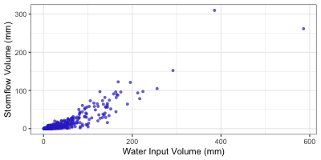

```r
events_df %>%
  ggplot(aes(x = waterInput_volume, y = stormflow_volume)) +
  geom_point(shape = 16, color = rgb(0.2, 0.2, 0.8, alpha = 0.7),
             size = 1) +
  labs(x = "Water Input Volume (mm)", y = "Stormflow Volume (mm)")
```

It seems there is hockey-stick pattern between event water input and stormflow volume. Let’s check the segmented model prediction performance for the stormflow generation of this catchment.

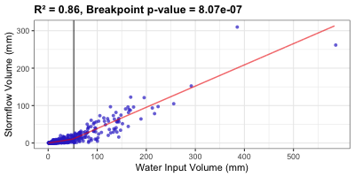

```r
# testing for one break point (threshold)
lm_model <- lm(stormflow_volume ~ waterInput_volume, data = events_df)
seg_model <- segmented(lm_model)
R2 <- round(summary(seg_model)$r.squared, 2)
pval <- formatC(pscore.test(seg_model)$p.value, format = "e", digits = 2)
threshold <- seg_model$psi[2]
x_interval <- seq(min(events_df$waterInput_volume),
                  max(events_df$waterInput_volume),
                  by = 0.1)
y_preds <- predict(seg_model,
                   newdata = data.frame(waterInput_volume = x_interval))

# as intercept might be negative let's remove negative predictions
y_preds <- y_preds[which(y_preds >= 0)]
x_interval <- x_interval[which(y_preds >= 0)]

ggplot() +
  geom_vline(xintercept = threshold, aes(color = "Threshold"),
             linewidth = 0.3, color = "black") +
  geom_point(
    data = events_df,
    aes(x = waterInput_volume, y = stormflow_volume),
    shape = 16, color = rgb(0.2, 0.2, 0.8, alpha = 0.7), size = 1
  ) +
  geom_line(
    aes(x = x_interval, y = y_preds), linewidth = 0.5, color = "red2",
    alpha = 0.6
  ) +
  labs(x = "Water Input Volume (mm)", y = "Stormflow Volume (mm)",
       subtitle = paste0("R\u00B2 = ", R2, ", ", "Breakpoint p-value = ", pval)) +
  theme(
      plot.subtitle = element_text(face = "bold", size = 9)
    ) +
  scale_x_continuous(
    breaks = seq(0, max(x_interval), 100),
    minor_breaks = seq(0, max(x_interval), 50)
  )
```

Since there is large slope difference before and after the threshold, let’s check the slope values:

```r
coef(seg_model)
```

```
#>            (Intercept)      waterInput_volume   U1.waterInput_volume psi1.waterInput_volume
#>             -0.6085027              0.2070575              0.3599823              0.0000000
```

This shows that slope before threshold is 0.21 and it increases to 0.57.

Baseflow signal with interpolation of event delimiter can be also calculated as follow:

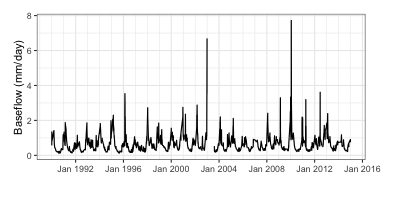

```r
baseflow_vals <- baseflow_extractor(
  water_input = test_catchment$precipitation_mmd,
  flow = test_catchment$streamflow_mmd,
  is_daily = TRUE, Rmin = 0.02, Lmax = 100
)

ggplot() +
  geom_line(aes(x = test_catchment$Date, y = baseflow_vals),
            linewidth = 0.4, color = "black") +
  labs(x = "", y = "Baseflow (mm/day)") +
  scale_x_date(
      date_breaks = "4 years",
      date_minor_breaks = "1 year",
      date_labels = "%b %Y"
    ) +
  theme(
    plot.margin = margin(t = 10, r = 25, b = 10, l = 10)
  )
```